# Chapter 7: Tibbles with `tibble`

Jonathan Bonaguro

## Excercises

1. How can you tell if an object is a tibble? (Hint: try printing mtcars, which is a regular data frame.)

**Answer:** You can tell if an object is a tibble in a few ways. One simple way is to use the command `is_tibble(x)`. If you have the output of a dataframe, it will tell you the dimesnion of the tibble, and print 10 rows of the data along with as many columns as it can fit *and* the column type.

2. Compare and contrast the following operations on a data.frame and equivalent tibble. What is different? Why might the default data frame behaviors cause you frustration?

```r
df <- data.frame(abc = 1, xyz = "a")
df
```

```
##   abc xyz
## 1   1   a
```

```r
df$x
```

```
## [1] a
## Levels: a
```

```r
df[, "xyz"]
```

```
## [1] a
## Levels: a
```

```r
df[, c("abc", "xyz")]
```

```
##   abc xyz
## 1   1   a
```

```r
tb <- as_tibble(df)
tb
```

```
## # A tibble: 1 x 2
##     abc xyz
##   <dbl> <fct>
## 1     1 a
```

```r
tb$x
tb[, "xyz"]
```

```
## # A tibble: 1 x 1
##   xyz
##   <fct>
## 1 a
```

```r
tb[, c("abc", "xyz")]
```

```
## # A tibble: 1 x 2
##     abc xyz
##   <dbl> <fct>
## 1     1 a
```

The brackets `[ , ]` returns either a vector or a dataframe from a dataframe depending on the number of columns selecting. When using bracks on a tibble, the brackets will always return a tibble.

3. If you have the name of a variable stored in an object, e.g., `var <- "mpg"`, how can you extract the reference variable from a tibble?

**Answer:** You can use the double bracket, `df[[var]]`.

4. Practice referring to nonsyntactic names in the following data frame by:
   1. Extracting the variable called 1.
   2. Plotting a scatterplot of 1 versus 2.
   3. Creating a new column called 3, which is 2 divided by 1.
   4. Renaming the columns to one, two, and three:

```r
annoying <- tibble(
  `1` = 1:10,
  `2` = `1` * 2 + rnorm(length(`1`))
)

# a. Extracting the variable called 1.
annoying[['1']]
```

```
##  [1]  1  2  3  4  5  6  7  8  9 10
```

```r
annoying$`1`
```

```
##  [1]  1  2  3  4  5  6  7  8  9 10
```

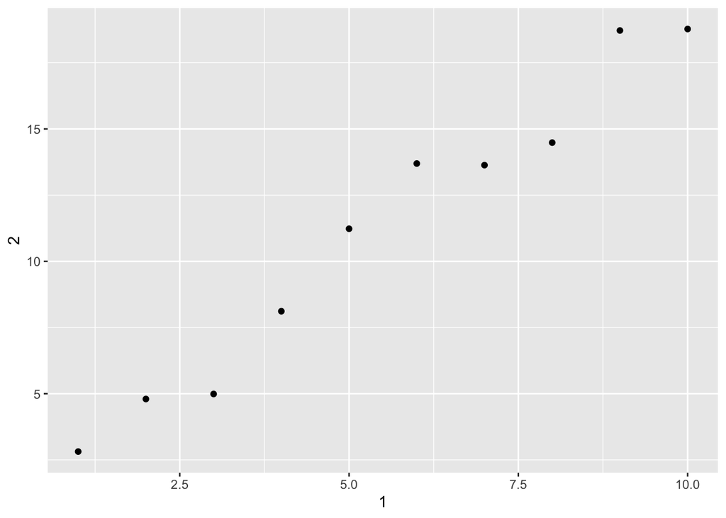

```r
# b. Plotting a scatterplot of 1 versus 2.
ggplot(annoying, aes(x = `1`, y = `2`)) +
  geom_point()
```

```r
# c. Creating a new column called 3, which is 2 divided by 1.
annoying[["3"]] = annoying[["2"]] / annoying[["1"]]
annoying$`3` = annoying$`2` / annoying$`1`

# d. Renaming the columns to one, two, and three:
rename(annoying, one = `1`, two = `2`, three = `3`)
```

```
## # A tibble: 10 x 3
##      one   two three
##    <int> <dbl> <dbl>
##  1     1  2.81  2.81
##  2     2  4.80  2.40
##  3     3  4.99  1.66
##  4     4  8.11  2.03
##  5     5 11.2   2.25
##  6     6 13.7   2.28
##  7     7 13.6   1.95
##  8     8 14.5   1.81
##  9     9 18.7   2.08
## 10    10 18.8   1.88
```

5. What does tibble::enframe() do? When might you use it?

**Answer:** `enframe()` converts named vectors to one or two column data frames. You might use it if you want to reshape data to do grouped analysis.

6. What option controls how many additional column names are printed at the footer of a tibble?

**Answer:** `n_extra` controls the number of extra column information printed.